# B32_Two_Qubits

| Abuzer Yakaryilmaz \| April 04, 2019 (updated) |
| --- |
| This cell contains some macros. If there is a problem with displaying mathematical formulas, please run this cell to load these macros. |

$ \newcommand{\bra}[1]{\langle #1|} $ $ \newcommand{\ket}[1]{|#1\rangle} $ $ \newcommand{\braket}[2]{\langle #1|#2\rangle} $ $ \newcommand{\dot}[2]{ #1 \cdot #2} $ $ \newcommand{\biginner}[2]{\left\langle #1,#2\right\rangle} $ $ \newcommand{\mymatrix}[2]{\left( \begin{array}{#1} #2\end{array} \right)} $ $ \newcommand{\myvector}[1]{\mymatrix{c}{#1}} $ $ \newcommand{\myrvector}[1]{\mymatrix{r}{#1}} $ $ \newcommand{\mypar}[1]{\left( #1 \right)} $ $ \newcommand{\mybigpar}[1]{ \Big( #1 \Big)} $ $ \newcommand{\sqrttwo}{\frac{1}{\sqrt{2}}} $ $ \newcommand{\dsqrttwo}{\dfrac{1}{\sqrt{2}}} $ $ \newcommand{\onehalf}{\frac{1}{2}} $ $ \newcommand{\donehalf}{\dfrac{1}{2}} $ $ \newcommand{\hadamard}{ \mymatrix{rr}{ \sqrttwo & \sqrttwo \\ \sqrttwo & -\sqrttwo }} $ $ \newcommand{\vzero}{\myvector{1\\0}} $ $ \newcommand{\vone}{\myvector{0\\1}} $ $ \newcommand{\vhadamardzero}{\myvector{ \sqrttwo \\ \sqrttwo } } $ $ \newcommand{\vhadamardone}{ \myrvector{ \sqrttwo \\ -\sqrttwo } } $ $ \newcommand{\myarray}[2]{ \begin{array}{#1}#2\end{array}} $ $ \newcommand{\X}{ \mymatrix{cc}{0 & 1 \\ 1 & 0} } $ $ \newcommand{\Z}{ \mymatrix{rr}{1 & 0 \\ 0 & -1} } $ $ \newcommand{\Htwo}{ \mymatrix{rrrr}{ \frac{1}{2} & \frac{1}{2} & \frac{1}{2} & \frac{1}{2} \\ \frac{1}{2} & -\frac{1}{2} & \frac{1}{2} & -\frac{1}{2} \\ \frac{1}{2} & \frac{1}{2} & -\frac{1}{2} & -\frac{1}{2} \\ \frac{1}{2} & -\frac{1}{2} & -\frac{1}{2} & \frac{1}{2} } } $ $ \newcommand{\CNOT}{ \mymatrix{cccc}{1 & 0 & 0 & 0 \\ 0 & 1 & 0 & 0 \\ 0 & 0 & 0 & 1 \\ 0 & 0 & 1 & 0} } $ $ \newcommand{\norm}[1]{ \left\lVert #1 \right\rVert } $

## Two Qubits

When we have a quantum system with two qubits, then we can represent its states as

$ \ket{00}, \ket{01}, \ket{10}, \ket{11} $.

The state $ \ket{ab} $ means that

- the first qubit is in state $ \ket{a} $ and
- the second qubit is in state $ \ket{b} $,

where $ a,b \in \{0,1\} $.

### Vector representation:

The vector representations of $ \ket{00}, \ket{01}, \ket{10}, \ket{11} $ are as follows:

$$ \ket{00} = \myvector{1 \\ 0 \\ 0 \\ 0}, ~~~~~~ \ket{01} = \myvector{0 \\ 1 \\ 0 \\ 0}, ~~~~~~ \ket{10} = \myvector{0 \\ 0 \\ 1 \\ 0}, ~~~ \mbox{ and } ~~~ \ket{11} = \myvector{0 \\ 0 \\ 0 \\ 1}. $$

The relation between state $ \ket{ab} $ and the states $ \ket{a} $ and $ \ket{b} $ is very simple:

$ \ket{ab} = \ket{a} \otimes \ket{b} $.

It is also shortly written as $ \ket{ab} = \ket{a} \ket{b} $ by omitting the tensor product operator.

Let's quickly verify each vector representation.

Remember that $ \ket{0} = \myvector{1 \\ 0} $ and $ \ket{1} = \myvector{0 \\ 1} $.

$$ \ket{00} = \ket{0} \otimes \ket{0} = \vzero \otimes \vzero = \myvector{1 \\ 0 \\ 0 \\ 0}. $$$$ \ket{01} = \ket{0} \otimes \ket{1} = \vzero \otimes \vone = \myvector{0 \\ 1 \\ 0 \\ 0}. $$$$ \ket{10} = \ket{1} \otimes \ket{0} = \vone \otimes \vzero = \myvector{0 \\ 0 \\ 1 \\ 0}. $$$$ \ket{11} = \ket{1} \otimes \ket{1} = \vone \otimes \vone = \myvector{0 \\ 0 \\ 0 \\ 1}. $$

### Applying Hadamards to both qubits

Applying h-gate to the first and second qubits is the same as applying the following single operator on both qubits:

$$ H^{\otimes 2} = H \otimes H = \hadamard \otimes \hadamard = \Htwo . $$

#### Case 1: Let's find $ H^{\otimes 2} \ket{00} $ (in three different ways)

- Direct matrix-vector multiplication: $$ H^{\otimes 2} \ket{00} = \Htwo \myvector{1 \\ 0 \\ 0 \\ 0} = \myvector{ \frac{1}{2} \\ \frac{1}{2} \\ \frac{1}{2} \\ \frac{1}{2} } . $$
- We calculate the quantum state of each state, and then find the quantum state of the composite system. $$ H\ket{0} \otimes H \ket{0} = \vhadamardzero \otimes \vhadamardzero = \myvector{ \frac{1}{2} \\ \frac{1}{2} \\ \frac{1}{2} \\ \frac{1}{2} }. $$
- We make calculations with $ \ket{0} $ and $ \ket{1} $. $$ H \ket{0} \otimes H \ket{0} = \mypar{ \frac{1}{\sqrt{2}} \ket{0} + \frac{1}{\sqrt{2}} \ket{1} } \otimes \mypar{ \frac{1}{\sqrt{2}} \ket{0} + \frac{1}{\sqrt{2}} \ket{1} } = \frac{1}{2} \ket{00} + \frac{1}{2} \ket{01} + \frac{1}{2} \ket{10} + \frac{1}{2} \ket{11} = \myvector{ \frac{1}{2} \\ \frac{1}{2} \\ \frac{1}{2} \\ \frac{1}{2} }. $$

### Task 1

Pick one of the following cases (2, 3, or 4), and verify the correctness of all three different ways for this selected case.

#### Case 2: Let's find $ H^{\otimes 2} \ket{01} $ (in three different ways)

- Direct matrix-vector multiplication: $$ H^{\otimes 2} \ket{01} = \Htwo \myvector{0 \\ 1 \\ 0 \\ 0} = \myrvector{ \frac{1}{2} \\ - \frac{1}{2} \\ \frac{1}{2} \\ - \frac{1}{2} } . $$
- We calculate the quantum state of each state, and then find the quantum state of the composite system. $$ H\ket{0} \otimes H \ket{1} = \vhadamardzero \otimes \vhadamardone = \myrvector{ \frac{1}{2} \\ - \frac{1}{2} \\ \frac{1}{2} \\ - \frac{1}{2} }. $$
- We make calculations with $ \ket{0} $ and $ \ket{1} $. $$ H \ket{0} \otimes H \ket{1} = \mypar{ \frac{1}{\sqrt{2}} \ket{0} + \frac{1}{\sqrt{2}} \ket{1} } \otimes \mypar{ \frac{1}{\sqrt{2}} \ket{0} - \frac{1}{\sqrt{2}} \ket{1} } = \frac{1}{2} \ket{00} - \frac{1}{2} \ket{01} + \frac{1}{2} \ket{10} - \frac{1}{2} \ket{11} = \myrvector{ \frac{1}{2} \\ - \frac{1}{2} \\ \frac{1}{2} \\ - \frac{1}{2} }. $$

#### Case 3: Let's find $ H^{\otimes 2} \ket{10} $ (in three different ways)

- Direct matrix-vector multiplication: $$ H^{\otimes 2} \ket{10} = \Htwo \myvector{0 \\ 0 \\ 1 \\ 0} = \myrvector{ \frac{1}{2} \\ \frac{1}{2} \\ - \frac{1}{2} \\ - \frac{1}{2} } . $$
- We calculate the quantum state of each state, and then find the quantum state of the composite system. $$ H\ket{1} \otimes H \ket{0} = \vhadamardone \otimes \vhadamardzero = \myrvector{ \frac{1}{2} \\ \frac{1}{2} \\ - \frac{1}{2} \\ - \frac{1}{2} }. $$
- We make calculations with $ \ket{0} $ and $ \ket{1} $. $$ H \ket{1} \otimes H \ket{0} = \mypar{ \frac{1}{\sqrt{2}} \ket{0} - \frac{1}{\sqrt{2}} \ket{1} } \otimes \mypar{ \frac{1}{\sqrt{2}} \ket{0} + \frac{1}{\sqrt{2}} \ket{1} } = \frac{1}{2} \ket{00} + \frac{1}{2} \ket{01} - \frac{1}{2} \ket{10} - \frac{1}{2} \ket{11} = \myrvector{ \frac{1}{2} \\ \frac{1}{2} \\ - \frac{1}{2} \\ -\frac{1}{2} }. $$

#### Case 4: Let's find $ H^{\otimes 2} \ket{11} $ (in three different ways)

- Direct matrix-vector multiplication: $$ H^{\otimes 2} \ket{11} = \Htwo \myvector{0 \\ 0 \\ 0 \\ 1} = \myrvector{ \frac{1}{2} \\ - \frac{1}{2} \\ - \frac{1}{2} \\ \frac{1}{2} } . $$
- We calculate the quantum state of each state, and then find the quantum state of the composite system. $$ H\ket{1} \otimes H \ket{1} = \vhadamardone \otimes \vhadamardone = \myrvector{ \frac{1}{2} \\ - \frac{1}{2} \\ - \frac{1}{2} \\ \frac{1}{2} }. $$
- We make calculations with $ \ket{0} $ and $ \ket{1} $. $$ H \ket{1} \otimes H \ket{1} = \mypar{ \frac{1}{\sqrt{2}} \ket{0} - \frac{1}{\sqrt{2}} \ket{1} } \otimes \mypar{ \frac{1}{\sqrt{2}} \ket{0} - \frac{1}{\sqrt{2}} \ket{1} } = \frac{1}{2} \ket{00} - \frac{1}{2} \ket{01} - \frac{1}{2} \ket{10} + \frac{1}{2} \ket{11} = \myrvector{ \frac{1}{2} \\ - \frac{1}{2} \\ - \frac{1}{2} \\ \frac{1}{2} }. $$

### CNOT operator

CNOT is an operator defined on two qubits:

$$ CNOT = \mymatrix{cccc}{1 & 0 & 0 & 0 \\ 0 & 1 & 0 & 0 \\ 0 & 0 & 0 & 1 \\ 0 & 0 & 1 & 0} . $$

Its effect is very simple: if the state of the first qubit is one, then the state of the second qubit is flipped.

If the state of the first bit is zero, then the state of the second qubit remains the same.

In summary:

- $ CNOT \ket{00} = \ket{00} $,
- $ CNOT \ket{01} = \ket{01} $,
- $ CNOT \ket{10} = \ket{11} $, and,
- $ CNOT \ket{11} = \ket{10} $.

CNOT refers to as Controlled-NOT: NOT operator is applied in a controlled way.

### cx-gate

In Qiskit, CNOT operator is represented as cx-gate.

It takes two arguments: controller-qubit and target-qubit.

Its implementation is as follows:

**x-gate** (NOT operator) is applied to the target qubit that is **CONTROLLED** by the controller qubit.

Let's apply CNOT to the states $ \ket{00}, \ket{01}, \ket{10}, \ket{11} $ by using python.

```python
# import all necessary objects and methods for quantum circuits
from qiskit import QuantumRegister, ClassicalRegister, QuantumCircuit, execute, Aer

# we use four pairs of two qubits in order to see all results at once
# the first pair -> qubits with indices 0 and 1
# the second pair -> qubits with indices 2 and 3
# the third pair -> qubits with indices 4 and 5
# the fourth pair -> qubits with indices 6 and 7
qreg =  QuantumRegister(8)
creg = ClassicalRegister(8)
mycircuit = QuantumCircuit(qreg,creg)

# the first pair is already in |00>

# the second pair is set to be in |01>
mycircuit.x(qreg[3])

# the third pair is set to be in |10>
mycircuit.x(qreg[4])

# the fourth pair is set to be in |11>
mycircuit.x(qreg[6])
mycircuit.x(qreg[7])

# apply cx to each pair
for i in range(0,8,2): # i = 0,2,4,6
    mycircuit.cx(qreg[i],qreg[i+1])

# measure the quantum register
mycircuit.measure(qreg,creg)

print("Everything looks fine, let's continue ...")
```

```
Everything looks fine, let's continue ...
```

```python
# draw the circuit

mycircuit.draw()
```

```
                                                                      ┌─┐
q0_0: |0>───────────────────────────────────────────────────────■─────┤M├
                                                              ┌─┴─┐┌─┐└╥┘
q0_1: |0>─────────────────────────────────────────────────────┤ X ├┤M├─╫─
                                                           ┌─┐└───┘└╥┘ ║
q0_2: |0>────────────────────────────────────────────■─────┤M├──────╫──╫─
                                              ┌───┐┌─┴─┐┌─┐└╥┘      ║  ║
q0_3: |0>─────────────────────────────────────┤ X ├┤ X ├┤M├─╫───────╫──╫─
                              ┌───┐        ┌─┐└───┘└───┘└╥┘ ║       ║  ║
q0_4: |0>─────────────────────┤ X ├──■─────┤M├───────────╫──╫───────╫──╫─
                              └───┘┌─┴─┐┌─┐└╥┘           ║  ║       ║  ║
q0_5: |0>──────────────────────────┤ X ├┤M├─╫────────────╫──╫───────╫──╫─
              ┌───┐        ┌─┐     └───┘└╥┘ ║            ║  ║       ║  ║
q0_6: |0>─────┤ X ├──■─────┤M├───────────╫──╫────────────╫──╫───────╫──╫─
         ┌───┐└───┘┌─┴─┐┌─┐└╥┘           ║  ║            ║  ║       ║  ║
q0_7: |0>┤ X ├─────┤ X ├┤M├─╫────────────╫──╫────────────╫──╫───────╫──╫─
         └───┘     └───┘└╥┘ ║            ║  ║            ║  ║       ║  ║
 c0_0: 0 ════════════════╬══╬════════════╬══╬════════════╬══╬═══════╬══╩═
                         ║  ║            ║  ║            ║  ║       ║
 c0_1: 0 ════════════════╬══╬════════════╬══╬════════════╬══╬═══════╩════
                         ║  ║            ║  ║            ║  ║
 c0_2: 0 ════════════════╬══╬════════════╬══╬════════════╬══╩════════════
                         ║  ║            ║  ║            ║
 c0_3: 0 ════════════════╬══╬════════════╬══╬════════════╩═══════════════
                         ║  ║            ║  ║
 c0_4: 0 ════════════════╬══╬════════════╬══╩════════════════════════════
                         ║  ║            ║
 c0_5: 0 ════════════════╬══╬════════════╩═══════════════════════════════
                         ║  ║
 c0_6: 0 ════════════════╬══╩════════════════════════════════════════════
                         ║
 c0_7: 0 ════════════════╩═══════════════════════════════════════════════
```

```python
# execute the circuit 1000 times in the local simulator

job = execute(mycircuit,Aer.get_backend('qasm_simulator'),shots=1000)
counts = job.result().get_counts(mycircuit)
# print the reverse of the output
for outcome in counts:
    reverse_outcome = ''
    for i in outcome:
        reverse_outcome = i + reverse_outcome
    print(reverse_outcome,"is observed",counts[outcome],"times")
    print()
    print("let's also split into the pairs")
    for i in range(0,8,2):
        print(reverse_outcome[i:i+2])
```

```
00011110 is observed 1000 times

let's also split into the pairs
00
01
11
10
```

### Task 2

Create a quantum curcuit with $ n=5 $ qubits.

Set each qubit to $ \ket{1} $.

Repeat 4 times:

- Randomly pick a pair of qubits, and apply cx-gate (CNOT operator) on the pair.

Draw your circuit, and execute your program 100 times.

Verify your measurement results by checking the diagram of the circuit.

```python
# import all necessary objects and methods for quantum circuits
from qiskit import QuantumRegister, ClassicalRegister, QuantumCircuit, execute, Aer
# import randrange for random choices
from random import randrange

#
# your code is here
#
qreg =  QuantumRegister(5)
creg = ClassicalRegister(5)
mycircuit = QuantumCircuit(qreg,creg)

# set each q-bit to 1
for i in range(5):
    mycircuit.x(qreg[i])

# Randomly pick pair of q-bits
r0 = randrange(5)
r1 = randrange(5)
while(r0 == r1 or r0+1 == r1 or r0+1 == r1 + 1 or r1+1 == r0):
    r0 = randrange(5)
    r1 = randrange(5)

# apply cx to selected pairs
for i in range(0,5):
    if i == r0 or i == r1:
        mycircuit.cx(qreg[i],qreg[i+1])

# measure the quantum register
mycircuit.measure(qreg,creg)
```

```
<qiskit.circuit.instructionset.InstructionSet at 0x12679c978>
```

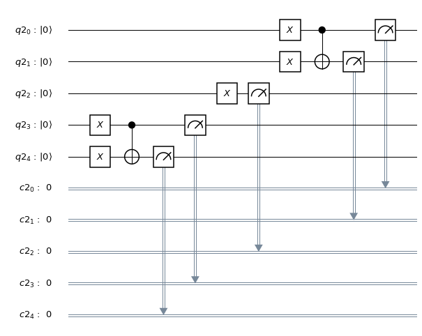

```python
# draw the circuit
mycircuit.draw(output='mpl')
```

```python
# execute the circuit 1000 times in the local simulator

job = execute(mycircuit,Aer.get_backend('qasm_simulator'),shots=1000)
counts = job.result().get_counts(mycircuit)
# print the reverse of the output
for outcome in counts:
    reverse_outcome = ''
    for i in outcome:
        reverse_outcome = i + reverse_outcome
    print(reverse_outcome,"is observed",counts[outcome],"times")
    print()
    print("let's also split into the pairs")
    for i in range(0,8,2):
        print(reverse_outcome[i:i+2])

print("randomly selected pairs: " + str(r0) + " " + str(r1))
```

```
10110 is observed 1000 times

let's also split into the pairs
10
11
0

randomly selected pairs: 3 0
```

click for our solution

### Task 3

Our task is to learn the behavior of the following quantum circuit by doing experiments.

Our circuit has two qubits.

- Apply Hadamard to the both qubits.
- Apply CNOT(first-qubit,second-qubit).
- Apply Hadamard to the both qubits.
- Measure the circuit.

Iteratively initialize the qubits to $ \ket{00} $, $ \ket{01} $, $ \ket{10} $, and $ \ket{11} $.

Execute your program 100 times for each iteration, and then check the outcomes for each iteration.

Verify that the overall circuit implements CNOT(second-qubit,first-qubit).

```python
# import all necessary objects and methods for quantum circuits
from qiskit import QuantumRegister, ClassicalRegister, QuantumCircuit, execute, Aer

#
# your code is here
#

# program has 8 q-bits
qreg =  QuantumRegister(8)
creg = ClassicalRegister(8)
mycircuit3 = QuantumCircuit(qreg,creg)

# Iteratively initialize q-bits as followa

# the first pair is set to be in |00>

# the second pair is set to be in |01>
mycircuit3.x(qreg[3])

# the third pair is set to be in |10>
mycircuit3.x(qreg[4])

# the third pair is set to be in |11>
mycircuit3.x(qreg[6])
mycircuit3.x(qreg[7])

# apply Hadamard to each pair
# apply cNot to every q-bit
# apply Hadamard to each pair
for i in range(8):
    mycircuit3.h(qreg[i])
for i in range(0,8,2): # i = 0,2,4,6
    mycircuit3.cx(qreg[i],qreg[i+1])
for i in range(8):
    mycircuit3.h(qreg[i])

# measure the quantum register
mycircuit3.measure(qreg,creg)
```

```
<qiskit.circuit.instructionset.InstructionSet at 0x129a6e358>
```

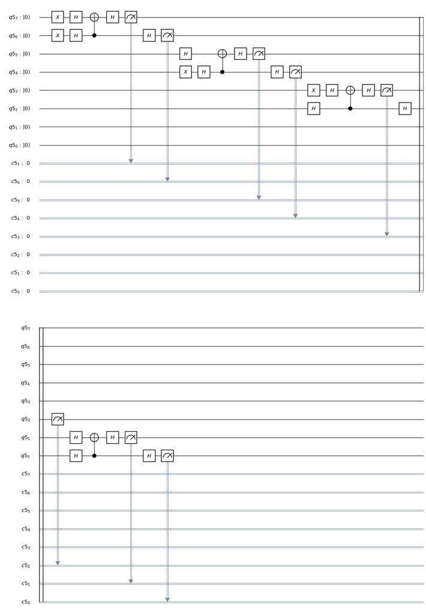

```python
# draw the circuit
mycircuit3.draw(output='mpl',reverse_bits=True)
# reexecute me if you DO NOT see the circuit diagram
```

```python
# execute the circuit 1000 times in the local simulator

job = execute(mycircuit3,Aer.get_backend('qasm_simulator'),shots=1000)
counts = job.result().get_counts(mycircuit3)
# print the reverse of the output
for outcome in counts:
    reverse_outcome = ''
    for i in outcome:
        reverse_outcome = i + reverse_outcome
    print(reverse_outcome,"is observed",counts[outcome],"times")
    print()
    print("let's also split into the pairs")
    for i in range(0,8,2):
        print(reverse_outcome[i:i+2])
```

```
00111001 is observed 1000 times

let's also split into the pairs
00
11
10
01
```

click for our solution

### Task 4

Our task is to learn the behavior of the following quantum circuit by doing experiments.

Our circuit has two qubits.

- Apply CNOT(first-qubit,second-qubit).
- Apply CNOT(second-qubit,first-qubit).
- Apply CNOT(first-qubit,second-qubit).

Iteratively initialize the qubits to $ \ket{00} $, $ \ket{01} $, $ \ket{10} $, and $ \ket{11} $.

Execute your program 100 times for each iteration, and then check the outcomes for each iteration.

Verify that the overall circuit swaps the values of the first and second qubits:

- $\ket{00} \rightarrow \ket{00} $
- $\ket{01} \rightarrow \ket{10} $
- $\ket{10} \rightarrow \ket{01} $
- $\ket{11} \rightarrow \ket{11} $

```python
# import all necessary objects and methods for quantum circuits
from qiskit import QuantumRegister, ClassicalRegister, QuantumCircuit, execute, Aer

#
# your code is here
#
# program has 8 q-bits
qreg =  QuantumRegister(8)
creg = ClassicalRegister(8)
mycircuit4 = QuantumCircuit(qreg,creg)

# Iteratively initialize q-bits as followa

# the first pair is set to be in |00>

# the second pair is set to be in |01>
mycircuit4.x(qreg[3])

# the third pair is set to be in |10>
mycircuit4.x(qreg[4])

# the third pair is set to be in |11>
mycircuit4.x(qreg[6])
mycircuit4.x(qreg[7])

# Apply C-NOT gates to pairs 3 times
# with different order
for i in range(0,8,2): # i = 0,2,4,6
    # first q-bit first
    mycircuit4.cx(qreg[i],qreg[i+1])
    # second q-bit first
    mycircuit4.cx(qreg[i+1],qreg[i])
    # first q-bit first
    mycircuit4.cx(qreg[i],qreg[i+1])

# measure the quantum register
mycircuit4.measure(qreg,creg)
```

```
<qiskit.circuit.instructionset.InstructionSet at 0x1299213c8>
```

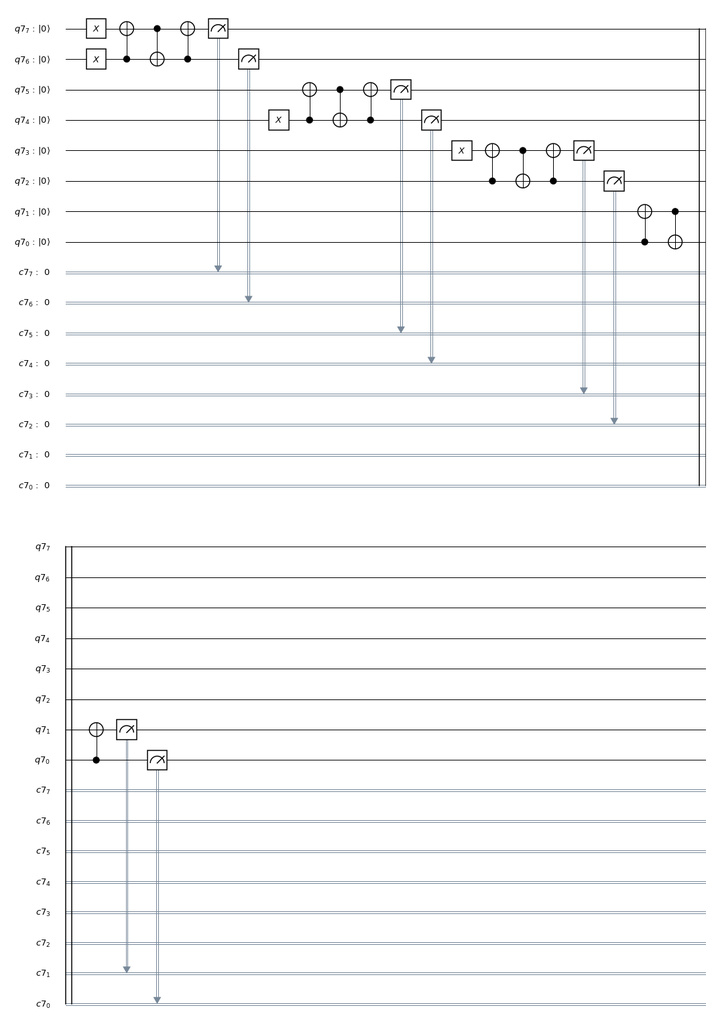

```python
# draw the circuit
mycircuit4.draw(output='mpl',reverse_bits=True)
# reexecute me if you DO NOT see the circuit diagram
```

```python
# execute the circuit 1000 times in the local simulator

job = execute(mycircuit4,Aer.get_backend('qasm_simulator'),shots=1000)
counts = job.result().get_counts(mycircuit4)
# print the reverse of the output
for outcome in counts:
    reverse_outcome = ''
    for i in outcome:
        reverse_outcome = i + reverse_outcome
    print(reverse_outcome,"is observed",counts[outcome],"times")
    print()
    print("let's also split into the pairs")
    for i in range(0,8,2):
        print(reverse_outcome[i:i+2])
```

```
00100111 is observed 1000 times

let's also split into the pairs
00
10
01
11
```

click for our solution